# Overview of scNMT data

### 2.3.1 Preprocessing

```r
met_raw <- fread("gastrulation_data/met/cpg_level/E4.5-5.5_new_Plate1_A03.tsv.gz")
met_raw
```

```
##         chr      pos met_reads nonmet_reads rate
##      1:   1  3020972         2            0    1
##      2:   1  3020988         2            0    1
##      3:   1  3022017         1            0    1
##      4:   1  3022571         1            0    1
##      5:   1  3022581         1            0    1
##     ---
## 467734:   Y 90810708         0            3    0
## 467735:   Y 90810761         0            1    0
## 467736:   Y 90811542         2            0    1
## 467737:   Y 90812328         1            0    1
## 467738:   Y 90812376         1            0    1
```

In the paper a descision was taken to binarize the data (i.e. representing each CpG/GpC site as methylated or unmethylated).

**Question: Take a look at the distribution of positive and negative reads. Can you see why the rate was binarized?**

**Answer**

A single cell should only have one methylation state at each CpG site (different methylation on the 2 alleles is rare). Thus any intermediate state likely comes from sequencing errors. In the histrogram we see that intermediate states are very rare.

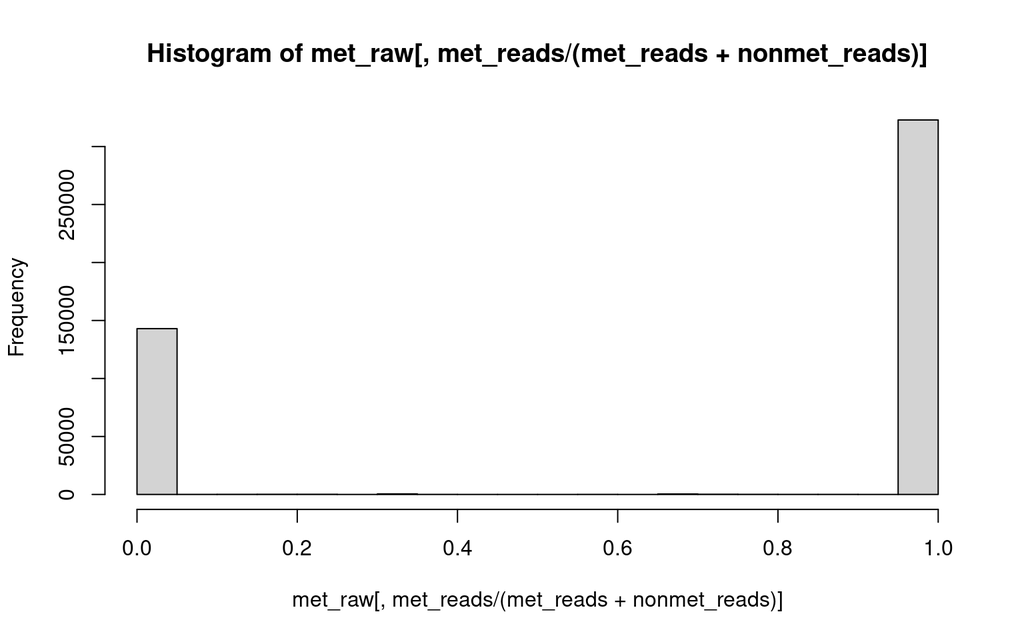

```r
hist(met_raw[, met_reads/(met_reads + nonmet_reads)])
```

Instead of our usual gene x cells count matrix, we are now working with a binary cell x CpG/GpC matrix for accessibility and methylation respectively. Additionally this matrix is extremely sparse. Have a look at [Supplementary Figure 1](https://www.nature.com/articles/s41586-019-1825-8#Fig5) from the paper. On average less than 1% of CpG sites are covered in any given cell. This means that it is very tough to make accurate assessments for single sites. For this reason it is often more useful to aggregate methylation and accessibility information over known regulatory regions. You can find some aggregated files in `gastrulation_data/met/feature_level/`. Let’s have a look at how this looks for gene promoters. We provide a dataset of promoter regions that extend 2000 bp to each side of the transcription start sites of genes.

```r
# Read promoter methylation
met_prom <- fread("gastrulation_data/met/feature_level/prom_2000_2000_clean.tsv.gz")
head(met_prom)
```

```
##                     sample                 id  N rate
## 1: E4.5-5.5_new_Plate1_A02 ENSMUSG00000000001  3   33
## 2: E4.5-5.5_new_Plate1_A02 ENSMUSG00000000028 29    7
## 3: E4.5-5.5_new_Plate1_A02 ENSMUSG00000000037  1  100
## 4: E4.5-5.5_new_Plate1_A02 ENSMUSG00000000049 22    5
## 5: E4.5-5.5_new_Plate1_A02 ENSMUSG00000000058  5    0
## 6: E4.5-5.5_new_Plate1_A02 ENSMUSG00000000078  6   67
```

In this table `sample` corresponds to the cell_id, `id` is the identifier for the genomic region, `N` is the number of CpG sites that the signal is based on and `rate` is the mean methylation rate. Let’s see how aggregating the individual signals affects the sparsity of the signal.

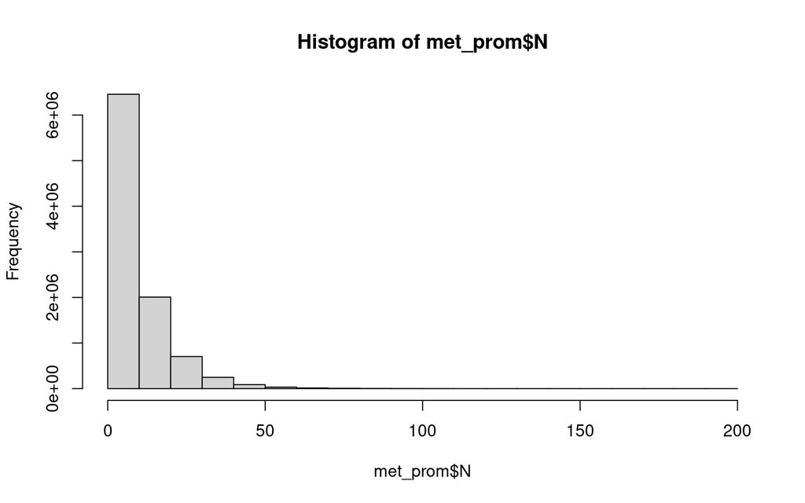

```r
hist(met_prom$N)
```

It is always important to check the distribution of our data. Let’s see how the aggregated rates are distributed.

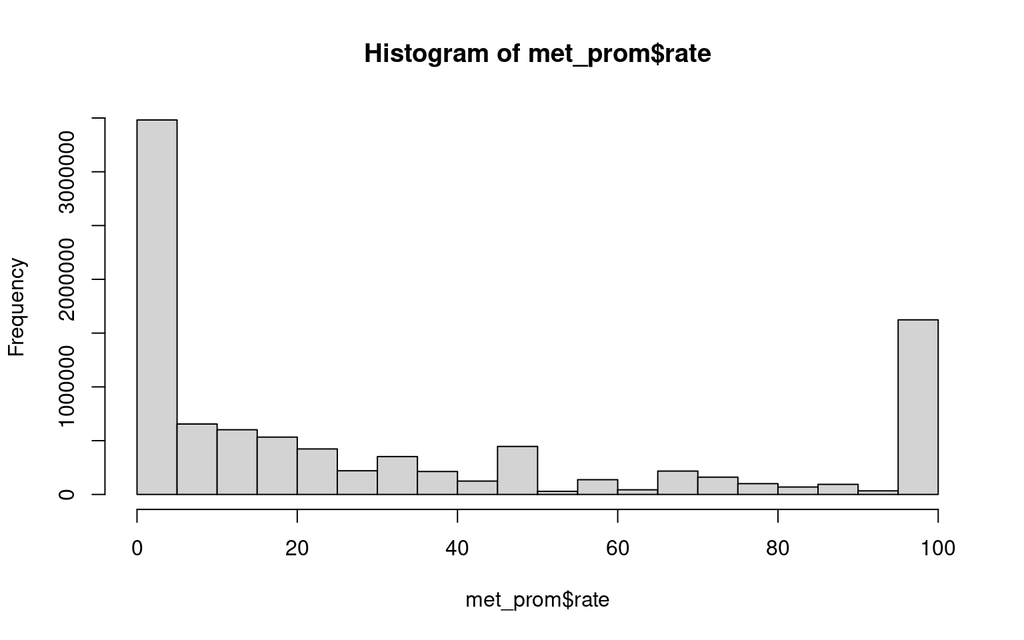

```r
hist(met_prom$rate)
```

This data is definitely not normally distributed. Analogous to the log-transfromation for the RNA expression data we should find a transformation that brings our data close to normal.

Here we will be working with M-values, which are calculated as `log2(((mean_rate/100)+0.01)/(1-(mean_rate/100)+0.01))`.

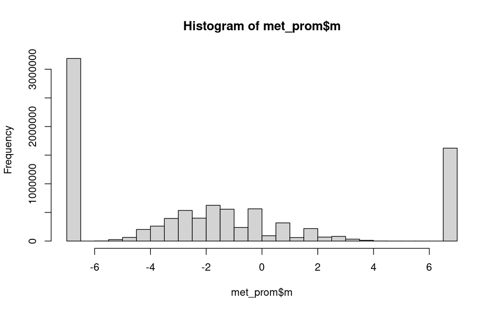

```r
met_prom[,m:=log2(((rate/100)+0.01)/(1-(rate/100)+0.01))]

hist(met_prom$m)
```

While this is still not normally distributed, it is much closer than before. In an ideal scenario we would use tools that can directly model the binomial nature of the data, but normalizing is common practice in many workflows.

### 2.3.2 Promoter methylation and gene expression

Promoter methylation is known to silence the expression of it’s gene. Let’s check if that is also the case in this dataset. We will calculate the correlation between gene expression and promoter methylation for each gene.

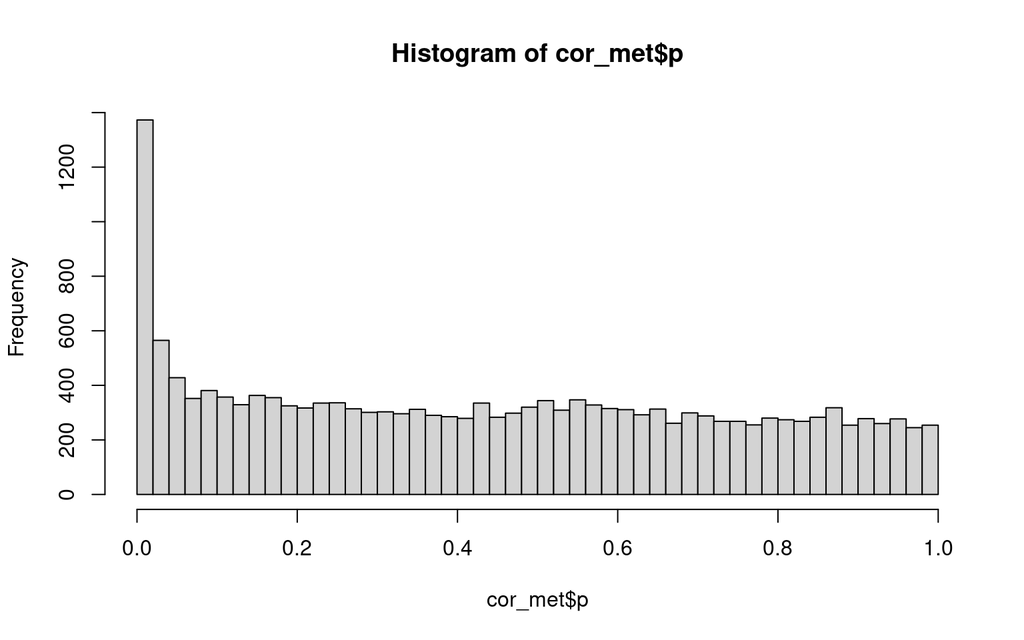

```r
# Make sure cells pass QC
cells <- metadata[pass_metQC == TRUE, sample]
met_prom <- met_prom[sample %in% cells]

# Filter by coverage
met_prom <- met_prom %>% .[,N:=.N, by="id"] %>% .[N>=50] %>% .[,N:=NULL]

# Get rna data in long format
rna_dt <- GetAssayData(rna) %>%
  as.data.table(keep.rownames = "id") %>%
  melt(id.vars = "id", variable.name = "sample", value.name = "expr")

# Merge met and rna information
metrna_dt <- merge(met_prom, rna_dt, by = c("id", "sample"))

# Compute correlations and test for significance
cor_met <- metrna_dt[, .(V1 = unlist(cor.test(m, expr)[c("estimate", "statistic", "p.value")])), by = "id"] %>%
  .[, para := rep(c("r","t","p"), .N/3)] %>% data.table::dcast(id ~ para, value.var = "V1") %>%
  .[, c("padj_fdr", "padj_bonf") := list(p.adjust(p, method="fdr"), p.adjust(p, method="bonferroni"))] %>%
  .[, c("log_padj_fdr","log_padj_bonf") := list(-log10(padj_fdr), -log10(padj_bonf))] %>%
  .[, sig := padj_fdr <= 0.1] %>%  setorder(padj_fdr) %>% .[!is.na(p)]

p1 <- hist(cor_met$p, breaks = 50)
```

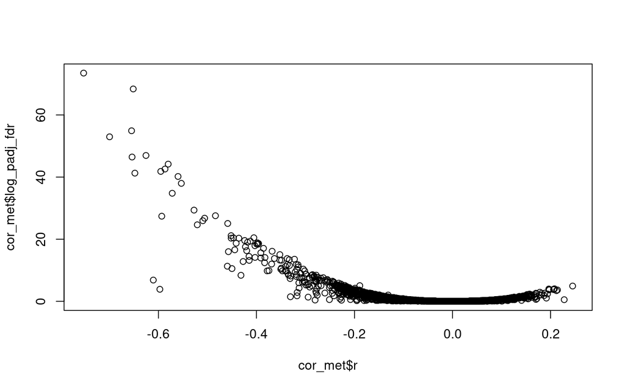

```r
p2 <- plot(cor_met$r, cor_met$log_padj_fdr)
```

**Question: How do you interpret this p-value histogram? Would you say this is well-behaved? What would you expect if none of the genes were anticorrelated to promoter methylation? What if almost all of the genes were?**

**Answer**

P-values are uniformly distributed between 0 and 1 if the null hypothesis is true. In a dataset where some tests come from the null and some from the alternative hypothesis we will observe a mixture of a uniform distribution and p-values close to 0. We can clearly see that most of our correlations are not significant, while a subset is.

### 2.3.3 Promoter acessibility and gene expression

We also have accessibility information for promoters. We will perform the same analysis, with a few modifications: - We are using windows of 200 bp around the TSS. This gives better results since our coverage is higher for acessibility. - We require 5 GpC sites to be detected in each cell and window. Again, we can do this since we have higher coverage.

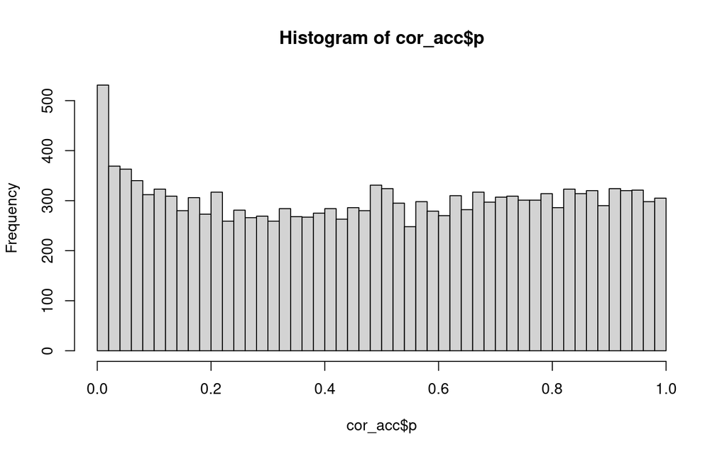

```r
# Read promoter accessibility
acc_prom <- fread("gastrulation_data/acc/feature_level/prom_200_200_clean.tsv.gz")

# Calculate m values
acc_prom[,m:=log2(((rate/100)+0.01)/(1-(rate/100)+0.01))]

cells <- metadata[pass_accQC == TRUE, sample]
acc_prom <- acc_prom[sample %in% cells]

# Filter for minimum number of GpC sites
acc_prom <- acc_prom[N >= 5]

# Filter by coverage
acc_prom <- acc_prom %>% .[,N:=.N, by="id"] %>% .[N>=50] %>% .[,N:=NULL]

accrna_dt <- merge(acc_prom, rna_dt, by = c("id", "sample"))

cor_acc <- accrna_dt[, .(V1 = unlist(cor.test(m, expr)[c("estimate", "statistic", "p.value")])), by = "id"] %>%
  .[, para := rep(c("r","t","p"), .N/3)] %>% data.table::dcast(id ~ para, value.var = "V1") %>%
  .[, c("padj_fdr", "padj_bonf") := list(p.adjust(p, method="fdr"), p.adjust(p, method="bonferroni"))] %>%
  .[, c("log_padj_fdr","log_padj_bonf") := list(-log10(padj_fdr), -log10(padj_bonf))] %>%
  .[, sig := padj_fdr <= 0.1] %>%  setorder(padj_fdr) %>% .[!is.na(p)]

p1 <- hist(cor_acc$p, breaks = 50)
```

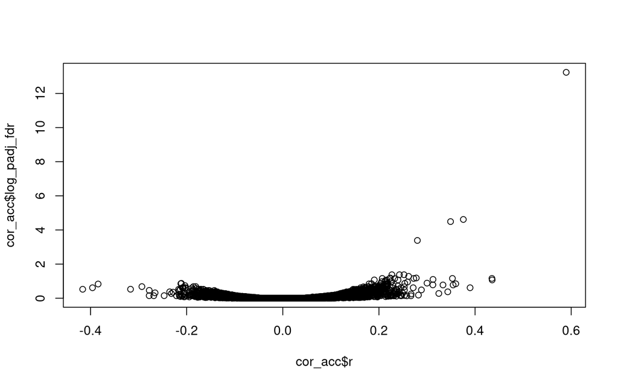

```r
p2 <- plot(cor_acc$r, cor_acc$log_padj_fdr)
```

Now we can reproduce Panel g of Figure 1.

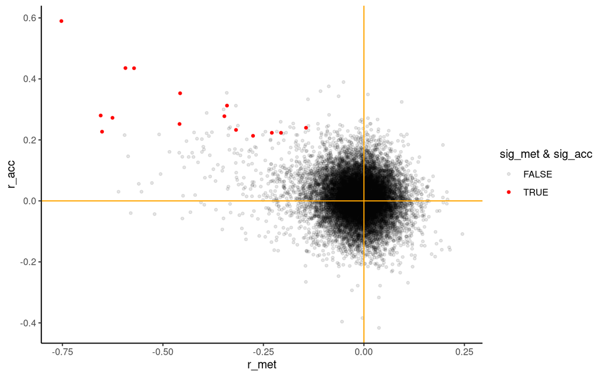

```r
plot_dt <- merge(cor_met, cor_acc, by = "id", suffixes = c("_met", "_acc"))
ggplot(plot_dt, aes(x = r_met, y = r_acc, color = sig_met & sig_acc)) +
  geom_point(size = 1, aes(alpha = sig_met & sig_acc)) +
  geom_hline(yintercept = 0, color = "orange", linewidth = 1) +
  geom_vline(xintercept = 0, color = "orange", linewidth = 1) +
  scale_color_manual(values = c("black", "red")) +
  theme_classic()
```

### 2.3.4 Visualization of individual genes

We will now look at a specific example gene in more detail. Specifically we will explore the promoter epigenetics of Dppa4 in relation to its expression.

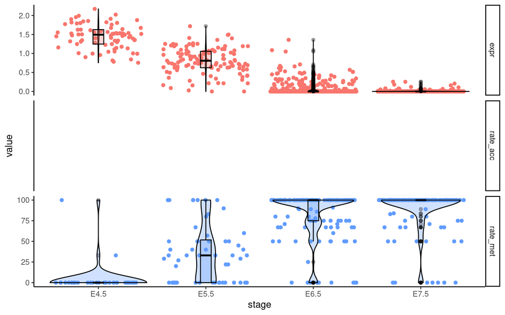

```r
gene_name <- "ENSMUSG00000058550"

# Merge together all 3 layers and metadata
all_layers <- rna_dt[id == gene_name] %>%
  #.[, rna_expression := logcounts(sce)[gene_name,][id_rna]] %>%
  merge(acc_prom[id == gene_name, c("sample", "rate")], by = c("sample"), all.x = T) %>%
  merge(met_prom[id == gene_name, c("sample", "rate")], by = c("sample"), all.x = T, suffixes = c("_acc","_met")) %>%
  merge(metadata, by = "sample")

plot_dt <- melt(all_layers, id.vars = c("sample", "stage"),
                measure.vars = c("expr", "rate_acc", "rate_met"),
                variable.name = "Layer")
plot_dt %>%
  ggplot(aes(x = stage, y = value, color = Layer, fill = Layer)) +
  geom_jitter() +
  geom_violin(alpha = 0.3, color = "black") +
  geom_boxplot(alpha = 0.3, width = 0.1, color = "black") +
  facet_grid(Layer~., scales = "free_y") +
  theme_classic() +
  theme(legend.position = "none")
```

We approximately reproduced panel 1h from the paper. Feel free to explore more genes on your own!

### 2.3.5 Dimensionality reduction of methylome

Now we will attempt to do dimensionality reduction with the methylome layer, to see if we get similar results to the UMAP of the RNA layer. As in the paper we will use DNAse hypersensitivity sites for this.

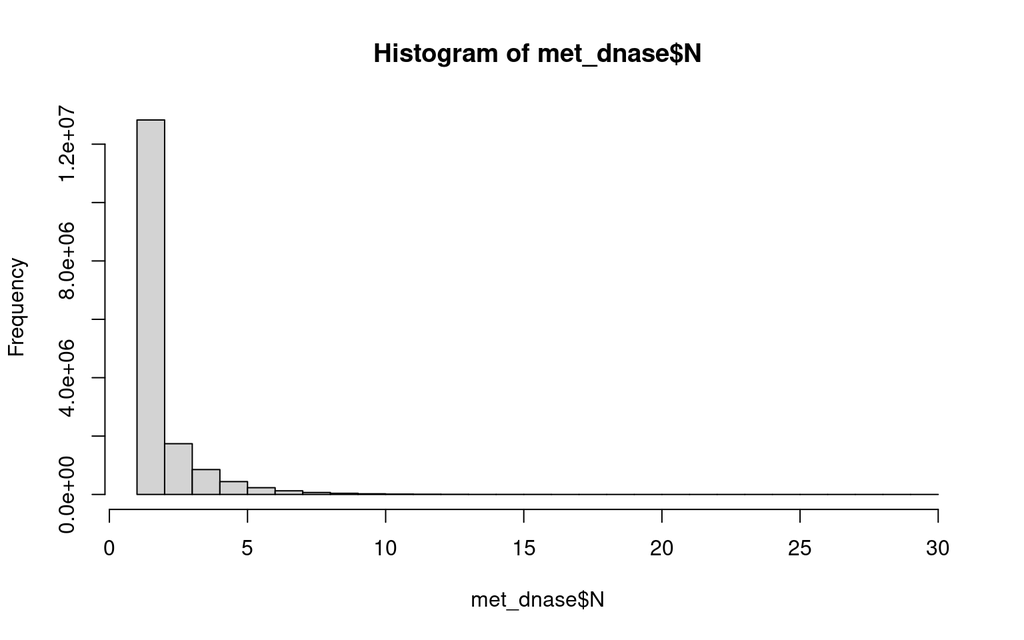

```r
met_dnase <- fread("gastrulation_data/met/feature_level/ESC_DHS_clean.tsv.gz")
# Keep only cells that pass the QC
cells <- metadata[pass_metQC == TRUE, sample]
met_dnase <- met_dnase[sample %in% cells]
hist(met_dnase$N)
```

Since the Signal is so sparse, we need a robust way of doing dimensionality reduction that can handle missing values. Linear Bayesian Factor analysis (which is the basis for MOFA) will work well in these scenarios. However some preprocessing of the data has to be done first. This is similar to the preprocessing of RNAseq data.

```r
# Calculate M value from Beta value
met_dnase[,m:=log2(((rate/100)+0.01)/(1-(rate/100)+0.01))]
```

The remaining preprocessing steps are: - We transform the `rate` value into `m` values to make them approximately normally distributed. - We filter out DNAse hypersensitivity sites that are covered by less than 10% of cells - We select only the 5000 most highly variable sites

```r
min_coverage = 0.10
n_hv = 5000

# Filter features by coverage
nsamples <- length(unique(met_dnase$sample))
met_dnase <- met_dnase %>% .[,cov:=.N/nsamples,by=id] %>%
  .[cov>=min_coverage] %>% .[,c("cov"):=NULL]

# Keep only highly variable sites
keep_hv_sites <- met_dnase %>%
  .[,.(var = var(rate)), by="id"] %>%
  .[var>0] %>% setorder(-var) %>%
  head(n = n_hv) %>% .$id

met_dnase <- met_dnase[id %in% keep_hv_sites]
```

Now we can transform the data into matrix format to run dimensionality reduction.

```r
met_mat <- dcast(met_dnase, formula = sample~id, value.var = "m") %>%
  tibble::column_to_rownames("sample") %>%
  as.matrix %>% t

met_mat[1:5, 1:5]
```

```
##                E4.5-5.5_new_Plate1_A02 E4.5-5.5_new_Plate1_A03
## ESC_DHS_100007                      NA                      NA
## ESC_DHS_100069                      NA               -6.658211
## ESC_DHS_10008                -6.658211                      NA
## ESC_DHS_100123                6.658211                      NA
## ESC_DHS_100129                      NA                      NA
##                E4.5-5.5_new_Plate1_A04 E4.5-5.5_new_Plate1_A07
## ESC_DHS_100007                      NA                      NA
## ESC_DHS_100069                      NA                      NA
## ESC_DHS_10008                       NA                      NA
## ESC_DHS_100123                      NA                      NA
## ESC_DHS_100129                      NA                6.658211
##                E4.5-5.5_new_Plate1_A08
## ESC_DHS_100007                      NA
## ESC_DHS_100069                      NA
## ESC_DHS_10008                       NA
## ESC_DHS_100123                6.658211
## ESC_DHS_100129                      NA
```

We will use `MOFA` for this Factor analysis. Note that this is not yet doing any multiomics integration. It is just a convenient way of performing Factor analysis.

```r
MOFAobject <- create_mofa(list(met_mat))
```

```
## Creating MOFA object from a list of matrices (features as rows, sample as columns)...
```

```
## No groups provided as argument... we assume that all samples are coming from the same group.
```

```
## View names are not specified in the data, using default: view_1
```

```r
# Set options
ModelOptions <- get_default_model_options(MOFAobject)
ModelOptions$num_factors <- 2

TrainOptions <- get_default_training_options(MOFAobject)
TrainOptions$seed <- 42

# Prepare
MOFAobject <- prepare_mofa(MOFAobject,
  model_options = ModelOptions,
  training_options = TrainOptions
)
```

```
## Checking data options...
```

```
## No data options specified, using default...
```

```
## Checking training options...
```

```
## Checking model options...
```

```r
# Train the model
model <- run_mofa(MOFAobject)
```

Let’s visualize the Factors.

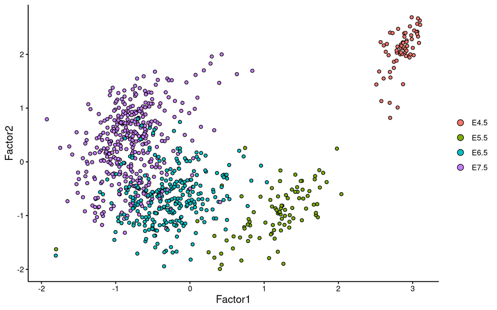

```r
metadata_plot <- metadata %>% setkey(sample) %>%
  .[samples_names(model)]
p <- plot_factors(
  model,
  factors = c(1,2),
  color_by = metadata_plot$stage
  )
p + scale_color_manual(values = stage_colors_met)
```

Great! The methylation rate within DNAse hypersensitive sites is clearly distinguishing cells of different stages. This means there is some regulation that we can further explore. We were also able to get similar results to Figure 1c from the paper.

```r
acc_dnase <- fread("gastrulation_data/acc/feature_level/ESC_DHS_clean.tsv.gz")
# Keep only cells that pass the QC
cells <- metadata[pass_accQC == TRUE, sample]
acc_dnase <- acc_dnase[sample %in% cells]
head(acc_dnase)
```

```
##                     sample             id N rate
## 1: E4.5-5.5_new_Plate1_A02     ESC_DHS_10 8   75
## 2: E4.5-5.5_new_Plate1_A02    ESC_DHS_100 6  100
## 3: E4.5-5.5_new_Plate1_A02 ESC_DHS_100003 8   88
## 4: E4.5-5.5_new_Plate1_A02 ESC_DHS_100012 2   50
## 5: E4.5-5.5_new_Plate1_A02 ESC_DHS_100013 7   29
## 6: E4.5-5.5_new_Plate1_A02 ESC_DHS_100014 4  100
```

We run the same preprocessing with slightly different parameters that were empirically found to work well. Feel free to explore how changing these influences the result.

```r
min_coverage = 0.10
n_hv = 10000
min_GpC = 5

# Filter for minimum number of GpC sites
acc_dnase <- acc_dnase[N >= min_GpC]

# Calculate M value from Beta value
acc_dnase[,m:=log2(((rate/100)+0.01)/(1-(rate/100)+0.01))]

# Filter features by coverage
nsamples <- length(unique(acc_dnase$sample))
acc_dnase <- acc_dnase[,cov:=.N/nsamples,by=id] %>%
  .[cov>=min_coverage] %>% .[,c("cov"):=NULL]

# Keep only highly variable sites
keep_hv_sites <- acc_dnase %>%
  .[,.(var = var(rate)), by="id"] %>%
  .[var>0] %>% setorder(-var) %>%
  head(n = n_hv) %>% .$id

acc_dnase <- acc_dnase[id %in% keep_hv_sites]
acc_dnase
```

```
##                           sample             id  N rate          m
##       1: E4.5-5.5_new_Plate1_A02 ESC_DHS_100055  5   60  0.5731853
##       2: E4.5-5.5_new_Plate1_A02 ESC_DHS_100153 10   30 -1.1955508
##       3: E4.5-5.5_new_Plate1_A02 ESC_DHS_100312  5    0 -6.6582115
##       4: E4.5-5.5_new_Plate1_A02 ESC_DHS_100349  6  100  6.6582115
##       5: E4.5-5.5_new_Plate1_A02 ESC_DHS_100366  8   88  2.7752937
##      ---
## 1257541:        PS_VE_Plate9_H08  ESC_DHS_99172  8    0 -6.6582115
## 1257542:        PS_VE_Plate9_H08  ESC_DHS_99278  9    0 -6.6582115
## 1257543:        PS_VE_Plate9_H08  ESC_DHS_99281  6   17 -2.2223924
## 1257544:        PS_VE_Plate9_H08  ESC_DHS_99692  9   89  2.9068906
## 1257545:        PS_VE_Plate9_H08  ESC_DHS_99940  5  100  6.6582115
```

```r
acc_mat <- dcast(acc_dnase, formula = sample~id, value.var = "m") %>%
  tibble::column_to_rownames("sample") %>%
  as.matrix %>% t

acc_mat[1:5, 1:5]
```

```
##                E4.5-5.5_new_Plate1_A02 E4.5-5.5_new_Plate1_A04
## ESC_DHS_1                           NA                      NA
## ESC_DHS_100040                      NA                      NA
## ESC_DHS_100055               0.5731853                      NA
## ESC_DHS_100098                      NA               6.6582115
## ESC_DHS_100110                      NA              -0.5731853
##                E4.5-5.5_new_Plate1_A07 E4.5-5.5_new_Plate1_A08
## ESC_DHS_1                           NA               6.6582115
## ESC_DHS_100040               -2.775294                      NA
## ESC_DHS_100055                      NA               0.6918777
## ESC_DHS_100098                      NA               2.5360529
## ESC_DHS_100110                6.658211               6.6582115
##                E4.5-5.5_new_Plate1_A12
## ESC_DHS_1                           NA
## ESC_DHS_100040                1.947533
## ESC_DHS_100055                      NA
## ESC_DHS_100098                      NA
## ESC_DHS_100110                      NA
```

Now we can create a mofa object and run the model.

```r
MOFAobject <- create_mofa(list(acc_mat))
```

```
## Creating MOFA object from a list of matrices (features as rows, sample as columns)...
```

```
## No groups provided as argument... we assume that all samples are coming from the same group.
```

```
## View names are not specified in the data, using default: view_1
```

```r
# Set options
ModelOptions <- get_default_model_options(MOFAobject)
ModelOptions$num_factors <- 2

TrainOptions <- get_default_training_options(MOFAobject)
TrainOptions$seed <- 42

# Prepare
MOFAobject <- prepare_mofa(MOFAobject,
  model_options = ModelOptions,
  training_options = TrainOptions
)
```

```
## Checking data options...
```

```
## No data options specified, using default...
```

```
## Checking training options...
```

```
## Checking model options...
```

```r
# Train the model
model_acc <- run_mofa(MOFAobject)
```

Let’s visualize the Factors

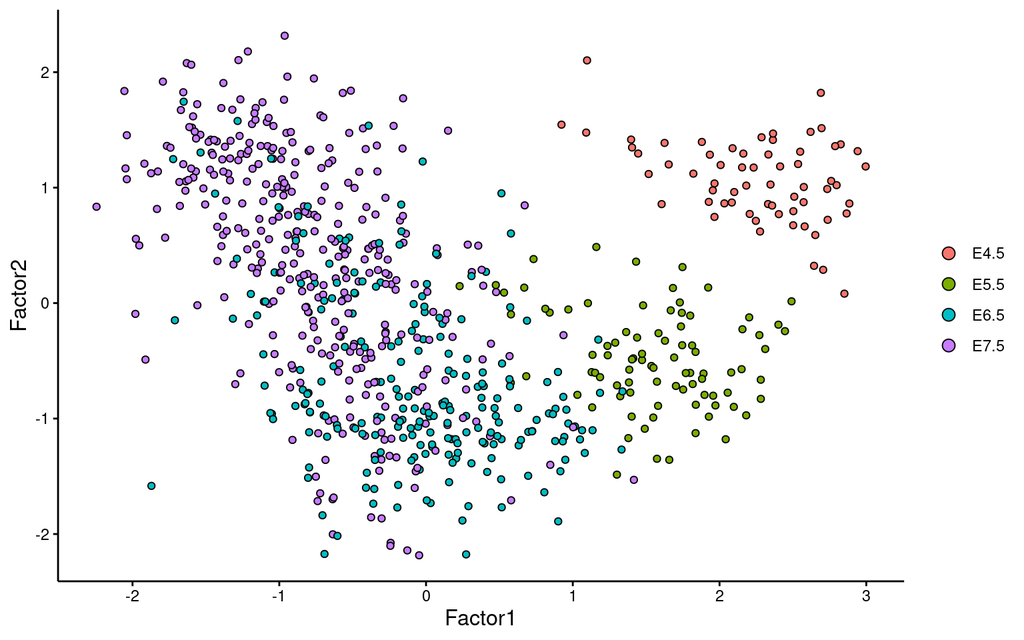

```r
metadata_plot <- metadata %>% setkey(sample) %>%
  .[samples_names(model_acc)]
p <- plot_factors(
  model_acc,
  factors = c(1,2),
  color_by = metadata_plot$stage
  )
p + scale_color_manual(values = stage_colors_acc)
```

This plot is similar to Figure 1d in the paper.

**Extra Question: Can you produce similar results with other dimensionality reduction methods that were introduced so far? (Note: you might have to impute the missing values for some of them to work)**